# Text analytics for large sets of customer feedback

11 August 2015

## Objectives

According to IBM, about *"80% of the information created and used by an enterprise is unstructured data, and this figure is growing at twice the rate of structured data”*.

Hence, it becomes imperative to **developed the required skills and tools to unlock this vast source of information** for critical business insights.

- The [accompanying app](https://phidesigner.shinyapps.io/Final_app) for this presentation, aims at exposing users to some of the most common, yet simple, techniques used for text mining, in an **interactive and simple way**.

Further information on text mining can be gathered from Yanchang Z. [Text Mining with R tutorials](http://www.rdatamining.com/examples/text-mining).

## Methodology

The app exposes users to simple text mining techniques, by allowing the interaction with three common Text Mining tools: **Word counting, Tree clustering and Kmeans analysis for word proximity**, through the following interactions:

- **1) Bar chart for word counting across all feedback:** Choose lower percentage threshold of word usage across all feedback (e.g. words used on at least 50 % of all feedback).
- **2) Dendogram of feedback’s natural clustering:** Choose max allowed sparsity threshold (i.e. resulting cluster contains only terms with a sparse factor of less than sparse value)
- **3) Verbatim of clusters by word proximity (K means):** Choose number of words per cluster, so as to better understand narrative.

## Dendogram chart example

### Promoter's feedback

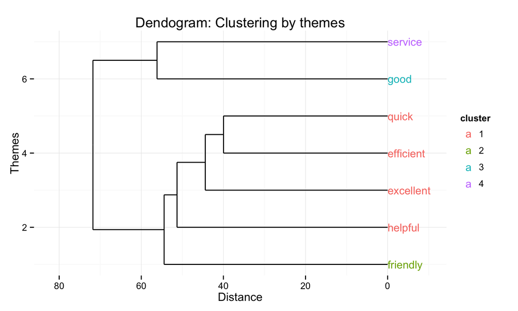

## Dendogram's code

```r
# Remove sparse terms
Promo_clust <- removeSparseTerms(tdm_Promo, sparse = 0.93)
Promo_matrix <- as.matrix(Promo_clust)
# Plotting cluster terms
dist_Promo <- dist(scale(Promo_matrix))
fit_Promo <- hclust(dist_Promo, method = "ward.D2")
dendr    <- dendro_data(fit_Promo, type="rectangle")
clust    <- cutree(fit_Promo,k=4)
clust.df <- data.frame(label=names(clust), cluster=factor(clust))
dendr[["labels"]] <- merge(dendr[["labels"]],clust.df, by="label")
# Dendogram plot
ggplot() + geom_segment(data=segment(dendr), aes(x=x, y=y,
          xend=xend, yend=yend)) + geom_text(data=label(dendr),
          aes(x, y, label=label, hjust=0, color=cluster),
          size=4) + theme_minimal() + coord_flip()
          + scale_y_reverse(expand=c(.2,0))
          + labs(title = "Dendogram: Clustering by themes",
          x = "Themes", y = "Distance")
```

… Thanks!

PS: This presentation was done in RStudio presenter using "output: ioslides_presentation" for the Data Science Specialisation (JHU/Coursera)